# RNAseq workflow using DESeq

## Workflow original

Este es el workflow de DESeq2, el original se encuentra en: https://bioconductor.org/packages/release/bioc/vignettes/DESeq2/inst/doc/DESeq2.html.

Ayuda en: https://support.bioconductor.org.

Si deseas utilizar esto en algún proyecto no te olvides de citar a los autores del paquete:

Love, M.I., Huber, W., Anders, S. (2014) Moderated estimation of fold change and dispersion for RNA-seq data with DESeq2. Genome Biology, 15:550. 10.1186/s13059-014-0550-8

## Quick start

Este código asume que ya cuentas con la matriz de cuentas en la variable cts, y una tabla con la información de las muestras en coldata. El diseño indica cómo modelar las muestras, en este caso se quiere medir el efecto de la condición, controlando las diferencias batch Las dos variables batch y condition deben ser columnas en coldata.

```r
# Do not run
#library(DESeq2)
#dds <- DESeqDataSetFromMatrix(countData = cts,
#                              colData = coldata,
#                              design= ~ batch + condition)
#dds <- DESeq(dds)
#resultsNames(dds) # lists the coefficients
#res <- results(dds, name="condition_trt_vs_untrt")
# or to shrink log fold changes association with condition:
#res <- lfcShrink(dds, coef="condition_trt_vs_untrt", type="apeglm")
```

## Desde los datos de entrada

Importante: Debes incorporar cuentas no normalizadas, o cuentas estimadas de lecturas de secuenciación DESEq2 internamente corrige los tamaños de librerías

Existen varias formas de incorporar los datos

- Método 1: A partir de archivos de abundancia de transcritos y tximport
- Método 2: A partir de una matriz de cuentas
- Método 3: A partir de archivos de htseq-count
- Método 4: A partir de un objeto SummarizedExperiment

# Método 1: A partir de archivos de abundancia de transcritos y tximport

```r
#library(DESeq2)
#library(tximport)
#library(readr)
#library(tximportData)
#dir <- system.file("extdata", package="tximportData")
#samples <- read.table(file.path(dir,"samples.txt"), header=TRUE)
#samples$condition <- factor(rep(c("A","B"),each=3))
#rownames(samples) <- samples$run
#samples[,c("pop","center","run","condition")]
#files <- file.path(dir,"salmon", samples$run, "quant.sf.gz")
#names(files) <- samples$run
#tx2gene <- read_csv(file.path(dir, "tx2gene.gencode.v27.csv"))
#txi <- tximport(files, type="salmon", tx2gene=tx2gene)
#ddsTxi <- DESeqDataSetFromTximport(txi,
#                                   colData = samples,
#                                   design = ~ condition)
```

# Método 2: A partir de una matriz de cuentas

```r
#library(DESeq2)
#library(pasilla)
#pasCts <- system.file("extdata",
#                      "pasilla_gene_counts.tsv",
#                      package="pasilla", mustWork=TRUE)
#pasAnno <- system.file("extdata",
#                       "pasilla_sample_annotation.csv",
#                       package="pasilla", mustWork=TRUE)
#cts <- as.matrix(read.csv(pasCts,sep="\t",row.names="gene_id"))
#coldata <- read.csv(pasAnno, row.names=1)
#coldata <- coldata[,c("condition","type")]
#coldata$condition <- factor(coldata$condition)
#coldata$type <- factor(coldata$type)
#head(cts,2)
#coldata
#rownames(coldata) <- sub("fb", "", rownames(coldata))
#all(rownames(coldata) %in% colnames(cts))
#all(rownames(coldata) == colnames(cts))
#cts <- cts[, rownames(coldata)]
#all(rownames(coldata) == colnames(cts))
#dds <- DESeqDataSetFromMatrix(countData = cts,
#                              colData = coldata,
#                              design = ~ condition)
#dds
```

# Método 3: A partir de archivos de htseq-count

```r
#library(DESeq2)
#directory <- "/path/to/your/files/"
#directory <- system.file("extdata", package="pasilla",
#                         mustWork=TRUE)
#sampleFiles <- grep("treated",list.files(directory),value=TRUE)
#sampleCondition <- sub("(.*treated).*","\\1",sampleFiles)
#sampleTable <- data.frame(sampleName = sampleFiles,
#                          fileName = sampleFiles,
#                          condition = sampleCondition)
#sampleTable$condition <- factor(sampleTable$condition)
#ddsHTSeq <- DESeqDataSetFromHTSeqCount(sampleTable = sampleTable,
#                                       directory = directory,
#                                       design= ~ condition)
#ddsHTSeq
```

# Método 4: A partir de un objeto SummarizedExperiment

```r
#library(DESeq2)
#library(airway)
#data("airway")
#se <- airway
#ddsSE <- DESeqDataSet(se, design = ~ cell + dex)
#ddsSE
```

## Dataset pasilla

Este es un experimento realizado en cultivos de Drosophila melanogaster, investigaron el efecto del knockdown de Pasilla, los datos se pueden obtener en GEO: GSM461176 a GSM461181 Autores del paquete: Wolfgang Huber, Alejandro Reyes <alejandro.reyes.ds at gmail.com>

```r
library(DESeq2)
library(pasilla)
pasCts <- system.file("extdata",
                      "pasilla_gene_counts.tsv",
                      package="pasilla", mustWork=TRUE) # para asegurarnos que haya un match
pasCts
```

```
## [1] "/usr/local/lib/R/site-library/pasilla/extdata/pasilla_gene_counts.tsv"
```

```r
pasAnno <- system.file("extdata",
                       "pasilla_sample_annotation.csv",
                       package="pasilla", mustWork=TRUE)
pasAnno
```

```
## [1] "/usr/local/lib/R/site-library/pasilla/extdata/pasilla_sample_annotation.csv"
```

```r
cts <- as.matrix(read.csv(pasCts, sep="\t", row.names="gene_id"))
head(cts)
```

```
##             untreated1 untreated2 untreated3 untreated4 treated1 treated2
## FBgn0000003          0          0          0          0        0        0
## FBgn0000008         92        161         76         70      140       88
## FBgn0000014          5          1          0          0        4        0
## FBgn0000015          0          2          1          2        1        0
## FBgn0000017       4664       8714       3564       3150     6205     3072
## FBgn0000018        583        761        245        310      722      299
##             treated3
## FBgn0000003        1
## FBgn0000008       70
## FBgn0000014        0
## FBgn0000015        0
## FBgn0000017     3334
## FBgn0000018      308
```

```r
coldata <- read.csv(pasAnno, row.names=1)
coldata
```

```
##              condition        type number.of.lanes total.number.of.reads
## treated1fb     treated single-read               5              35158667
## treated2fb     treated  paired-end               2         12242535 (x2)
## treated3fb     treated  paired-end               2         12443664 (x2)
## untreated1fb untreated single-read               2              17812866
## untreated2fb untreated single-read               6              34284521
## untreated3fb untreated  paired-end               2         10542625 (x2)
## untreated4fb untreated  paired-end               2         12214974 (x2)
##              exon.counts
## treated1fb      15679615
## treated2fb      15620018
## treated3fb      12733865
## untreated1fb    14924838
## untreated2fb    20764558
## untreated3fb    10283129
## untreated4fb    11653031
```

```r
coldata <- coldata[,c("condition","type")]
coldata
```

```
##              condition        type
## treated1fb     treated single-read
## treated2fb     treated  paired-end
## treated3fb     treated  paired-end
## untreated1fb untreated single-read
## untreated2fb untreated single-read
## untreated3fb untreated  paired-end
## untreated4fb untreated  paired-end
```

```r
coldata$condition <- factor(coldata$condition)
coldata$type <- factor(coldata$type)
str(coldata)
```

```
## 'data.frame':    7 obs. of  2 variables:
##  $ condition: Factor w/ 2 levels "treated","untreated": 1 1 1 2 2 2 2
##  $ type     : Factor w/ 2 levels "paired-end","single-read": 2 1 1 2 2 1 1
```

```r
head(cts,2)
```

```
##             untreated1 untreated2 untreated3 untreated4 treated1 treated2
## FBgn0000003          0          0          0          0        0        0
## FBgn0000008         92        161         76         70      140       88
##             treated3
## FBgn0000003        1
## FBgn0000008       70
```

```r
coldata
```

```
##              condition        type
## treated1fb     treated single-read
## treated2fb     treated  paired-end
## treated3fb     treated  paired-end
## untreated1fb untreated single-read
## untreated2fb untreated single-read
## untreated3fb untreated  paired-end
## untreated4fb untreated  paired-end
```

No están en el mismo orden con respecto a las muestras!!!! ES ABSOLUTAMENTE CRÍTICO que las columnas de la matriz de cuentas y la información de las muestras (las filas) estén en el mismo orden. DESeq2 no adivina cuál columna de la matriz de cuentas corresponde con cuál fila de la información de las muestras, se los debemos dar en el orden de forma consistente. Nosotros debemos reordenarlos, sino después se puede producir un error. También hay que quitarle el “fb” a los datos para que el nombre sea consistente

```r
rownames(coldata) <- sub("fb", "", rownames(coldata))
head(coldata)
```

```
##            condition        type
## treated1     treated single-read
## treated2     treated  paired-end
## treated3     treated  paired-end
## untreated1 untreated single-read
## untreated2 untreated single-read
## untreated3 untreated  paired-end
```

```r
all(rownames(coldata) %in% colnames(cts))
```

```
## [1] TRUE
```

```r
all(rownames(coldata) == colnames(cts))
```

```
## [1] FALSE
```

```r
head(cts)
```

```
##             untreated1 untreated2 untreated3 untreated4 treated1 treated2
## FBgn0000003          0          0          0          0        0        0
## FBgn0000008         92        161         76         70      140       88
## FBgn0000014          5          1          0          0        4        0
## FBgn0000015          0          2          1          2        1        0
## FBgn0000017       4664       8714       3564       3150     6205     3072
## FBgn0000018        583        761        245        310      722      299
##             treated3
## FBgn0000003        1
## FBgn0000008       70
## FBgn0000014        0
## FBgn0000015        0
## FBgn0000017     3334
## FBgn0000018      308
```

```r
cts <- cts[, rownames(coldata)]
head(cts)
```

```
##             treated1 treated2 treated3 untreated1 untreated2 untreated3
## FBgn0000003        0        0        1          0          0          0
## FBgn0000008      140       88       70         92        161         76
## FBgn0000014        4        0        0          5          1          0
## FBgn0000015        1        0        0          0          2          1
## FBgn0000017     6205     3072     3334       4664       8714       3564
## FBgn0000018      722      299      308        583        761        245
##             untreated4
## FBgn0000003          0
## FBgn0000008         70
## FBgn0000014          0
## FBgn0000015          2
## FBgn0000017       3150
## FBgn0000018        310
```

```r
all(rownames(coldata) == colnames(cts))
```

```
## [1] TRUE
```

Ya que tenemos los datos, ahora si podemos construir el objeto DESeqDataSet

```r
dds <- DESeqDataSetFromMatrix(countData = cts,
                              colData = coldata,
                              design = ~ condition)
dds
```

```
## class: DESeqDataSet
## dim: 14599 7
## metadata(1): version
## assays(1): counts
## rownames(14599): FBgn0000003 FBgn0000008 ... FBgn0261574 FBgn0261575
## rowData names(0):
## colnames(7): treated1 treated2 ... untreated3 untreated4
## colData names(2): condition type
```

```r
class(dds)
```

```
## [1] "DESeqDataSet"
## attr(,"package")
## [1] "DESeq2"
```

```r
# Break - claseS4
isS4(dds)
```

```
## [1] TRUE
```

Si tuviéramos datos adicionales podemos integrarlos añadiendo columnas a los metadatos Aquí estamos añadiendo datos redundantes solo para hacer la demostración, ya que ya tenemos los nombres de los genes en las filas de dds

```r
featureData <- data.frame(gene=rownames(cts))
head(featureData)
```

```
##          gene
## 1 FBgn0000003
## 2 FBgn0000008
## 3 FBgn0000014
## 4 FBgn0000015
## 5 FBgn0000017
## 6 FBgn0000018
```

```r
mcols(dds) # mcols es metadata colummns
```

```
## DataFrame with 14599 rows and 0 columns
```

```r
mcols(dds) <- DataFrame(mcols(dds), featureData)
mcols(dds)
```

```
## DataFrame with 14599 rows and 1 column
##                    gene
##             <character>
## FBgn0000003 FBgn0000003
## FBgn0000008 FBgn0000008
## FBgn0000014 FBgn0000014
## FBgn0000015 FBgn0000015
## FBgn0000017 FBgn0000017
## ...                 ...
## FBgn0261571 FBgn0261571
## FBgn0261572 FBgn0261572
## FBgn0261573 FBgn0261573
## FBgn0261574 FBgn0261574
## FBgn0261575 FBgn0261575
```

## Prefiltrado

Aunque no es necesario pre-filatar los genes con conteos bajos cuando corremos las funciones de DESeq2, hay dos razones por las cuales vale la pena hacerlo, si eliminamos las filas en las que no hay muchos reads, 1. reducimos el tamaño de memoria del objeto dds, 2. incrementamos la velocidad al trabajar con las funciones de DESEq2

```r
keep <- rowSums(counts(dds)) >= 10
dds <- dds[keep,]
dds
```

```
## class: DESeqDataSet
## dim: 9921 7
## metadata(1): version
## assays(1): counts
## rownames(9921): FBgn0000008 FBgn0000014 ... FBgn0261574 FBgn0261575
## rowData names(1): gene
## colnames(7): treated1 treated2 ... untreated3 untreated4
## colData names(2): condition type
```

## Pon atención a los niveles

R elige el nivel de referencia para los factores en orden alfabético, si no le dices a DESeq2, que nivel quieres comparar contra qué (tratamiento vs control) entonces las comparaciones se realizarán en el orden alfabético de los niveles

Solución 1: Especificar en results cuál comparación se realizará usando el argumento contrast Solución 2: Definir los niveles

```r
# Opción 1
dds$condition <- factor(dds$condition, levels = c("untreated","treated"))
dds$condition
```

```
## [1] treated   treated   treated   untreated untreated untreated untreated
## Levels: untreated treated
```

```r
# Opción 2
#dds$condition <- relevel(dds$condition, ref = "untreated")

# Si se eliminaron muestras, también hay que eliminar sus niveles
#dds$condition <- droplevels(dds$condition)
```

## Análisis de expresión diferencial

El modelo DESeq2 está descrito en detalle en la publicación (Love, Huber, and Anders 2014), realiza una normalización interna, se calcula una media geométrica para cada gen a través de todas las muestras. Las cuentas para cada gen en cada muestra se dividen por esta media. La mediana de estas tasas en una muestra es el size factor para esa muestra. Este procedimiento corrige el tamaño de las librerías y el bias de la composición de RNA, que puede surgir por ejemplo cuando un número pequeño de genes se expresa muy alto en una condición experimental pero no en otra. Cuando se tiene un número pequeño de réplicas es difícil estimar la varianza intra-grupo con confianaza, DESeq2 usa una estimación shrinkage para dispersiones y fold changes. Un valor de dispersión se estima para cada gen con un modelo de ajuste. Necesitas un número suficiente de réplicas biológicas para estimar la dispersión de forma apropiada. Si no hay, entonces DESeq la estima usando muestras de las diferentes condiciones como si fueran réplicas. DESeq ajusta modelos lineales generalizados de binomial negativa para cada gen y usa la prueba Wald para significancia estadística. Además de la información de grupo es posible que ustedes puedan darle información adicional para pareados en el análisis.

```r
dds <- DESeq(dds)
dds
```

```
## class: DESeqDataSet
## dim: 9921 7
## metadata(1): version
## assays(4): counts mu H cooks
## rownames(9921): FBgn0000008 FBgn0000014 ... FBgn0261574 FBgn0261575
## rowData names(23): gene baseMean ... deviance maxCooks
## colnames(7): treated1 treated2 ... untreated3 untreated4
## colData names(3): condition type sizeFactor
```

La salida significa lo siguiente: baseMean = promedio de las cuentas normalizadas en todas las muestras log2FoldChange = entre los grupos, un valor de 2 significa que se incrementó 4 veces lfcSE = error estándar del estimado log2Foldchange stat = estadística Wald pvalue = p-value de la prueba Wald padj = ajuste Benjamini-Hochberg

```r
res <- results(dds)
res
```

```
## log2 fold change (MLE): condition treated vs untreated
## Wald test p-value: condition treated vs untreated
## DataFrame with 9921 rows and 6 columns
##               baseMean log2FoldChange     lfcSE       stat    pvalue      padj
##              <numeric>      <numeric> <numeric>  <numeric> <numeric> <numeric>
## FBgn0000008   95.14429     0.00227644  0.223729   0.010175 0.9918817  0.997211
## FBgn0000014    1.05652    -0.49512039  2.143186  -0.231021 0.8172987        NA
## FBgn0000017 4352.55357    -0.23991894  0.126337  -1.899041 0.0575591  0.288002
## FBgn0000018  418.61048    -0.10467391  0.148489  -0.704927 0.4808558  0.826834
## FBgn0000024    6.40620     0.21084779  0.689588   0.305759 0.7597879  0.943501
## ...                ...            ...       ...        ...       ...       ...
## FBgn0261570 3208.38861      0.2955329  0.127350  2.3206264  0.020307  0.144240
## FBgn0261572    6.19719     -0.9588230  0.775315 -1.2366888  0.216203  0.607848
## FBgn0261573 2240.97951      0.0127194  0.113300  0.1122634  0.910615  0.982657
## FBgn0261574 4857.68037      0.0153924  0.192567  0.0799327  0.936291  0.988179
## FBgn0261575   10.68252      0.1635705  0.930911  0.1757102  0.860522  0.967928
```

```r
# Otras opciones para especificar el contraste
# res <- results(dds, name="condition_treated_vs_untreated")
# res <- results(dds, contrast=c("condition","treated","untreated"))
```

## Log fold change shrinkage - visualización y ranking

```r
resultsNames(dds)
```

```
## [1] "Intercept"                      "condition_treated_vs_untreated"
```

```r
resLFC <- lfcShrink(dds, coef="condition_treated_vs_untreated", type="apeglm")
```

```
## using 'apeglm' for LFC shrinkage. If used in published research, please cite:
##     Zhu, A., Ibrahim, J.G., Love, M.I. (2018) Heavy-tailed prior distributions for
##     sequence count data: removing the noise and preserving large differences.
##     Bioinformatics. https://doi.org/10.1093/bioinformatics/bty895
```

```r
resLFC
```

```
## log2 fold change (MAP): condition treated vs untreated
## Wald test p-value: condition treated vs untreated
## DataFrame with 9921 rows and 5 columns
##               baseMean log2FoldChange     lfcSE    pvalue      padj
##              <numeric>      <numeric> <numeric> <numeric> <numeric>
## FBgn0000008   95.14429     0.00119920  0.151897 0.9918817  0.997211
## FBgn0000014    1.05652    -0.00473412  0.205468 0.8172987        NA
## FBgn0000017 4352.55357    -0.18989990  0.120377 0.0575591  0.288002
## FBgn0000018  418.61048    -0.06995753  0.123901 0.4808558  0.826834
## FBgn0000024    6.40620     0.01752715  0.198633 0.7597879  0.943501
## ...                ...            ...       ...       ...       ...
## FBgn0261570 3208.38861     0.24110290 0.1244469  0.020307  0.144240
## FBgn0261572    6.19719    -0.06576173 0.2141351  0.216203  0.607848
## FBgn0261573 2240.97951     0.01000619 0.0993764  0.910615  0.982657
## FBgn0261574 4857.68037     0.00843552 0.1408267  0.936291  0.988179
## FBgn0261575   10.68252     0.00809101 0.2014704  0.860522  0.967928
```

## Ordenamos por el p-value mas pequeño

```r
resOrdered <- res[order(res$pvalue),]
resOrdered
```

```
## log2 fold change (MLE): condition treated vs untreated
## Wald test p-value: condition treated vs untreated
## DataFrame with 9921 rows and 6 columns
##              baseMean log2FoldChange     lfcSE         stat       pvalue
##             <numeric>      <numeric> <numeric>    <numeric>    <numeric>
## FBgn0039155   730.568       -4.61874 0.1691240     -27.3098 3.24447e-164
## FBgn0025111  1501.448        2.89995 0.1273576      22.7701 9.07165e-115
## FBgn0029167  3706.024       -2.19691 0.0979154     -22.4368 1.72030e-111
## FBgn0003360  4342.832       -3.17954 0.1435677     -22.1466 1.12417e-108
## FBgn0035085   638.219       -2.56024 0.1378126     -18.5777  4.86845e-77
## ...               ...            ...       ...          ...          ...
## FBgn0051913   2.75973   -0.001450714  1.239864 -0.001170059     0.999066
## FBgn0037061 144.76833    0.000314936  0.290635  0.001083616     0.999135
## FBgn0036689 117.56024   -0.000228957  0.214822 -0.001065801     0.999150
## FBgn0046272   6.54031   -0.001980640  2.439802 -0.000811803     0.999352
## FBgn0030880  13.00577   -6.969572683  3.681447 -1.893161117           NA
##                     padj
##                <numeric>
## FBgn0039155 2.71919e-160
## FBgn0025111 3.80147e-111
## FBgn0029167 4.80595e-108
## FBgn0003360 2.35542e-105
## FBgn0035085  8.16049e-74
## ...                  ...
## FBgn0051913           NA
## FBgn0037061     0.999269
## FBgn0036689     0.999269
## FBgn0046272     0.999352
## FBgn0030880           NA
```

```r
summary(res)
```

```
##
## out of 9921 with nonzero total read count
## adjusted p-value < 0.1
## LFC > 0 (up)       : 518, 5.2%
## LFC < 0 (down)     : 536, 5.4%
## outliers [1]       : 1, 0.01%
## low counts [2]     : 1539, 16%
## (mean count < 6)
## [1] see 'cooksCutoff' argument of ?results
## [2] see 'independentFiltering' argument of ?results
```

¿Cuántos p-values ajustados serán menores a 0.1?

```r
sum(res$padj < 0.1, na.rm=TRUE)
```

```
## [1] 1054
```

```r
res05 <- results(dds, alpha=0.05)
summary(res05)
```

```
##
## out of 9921 with nonzero total read count
## adjusted p-value < 0.05
## LFC > 0 (up)       : 407, 4.1%
## LFC < 0 (down)     : 431, 4.3%
## outliers [1]       : 1, 0.01%
## low counts [2]     : 1347, 14%
## (mean count < 5)
## [1] see 'cooksCutoff' argument of ?results
## [2] see 'independentFiltering' argument of ?results
```

```r
sum(res05$padj < 0.05, na.rm=TRUE)
```

```
## [1] 838
```

## Explorando los resultados

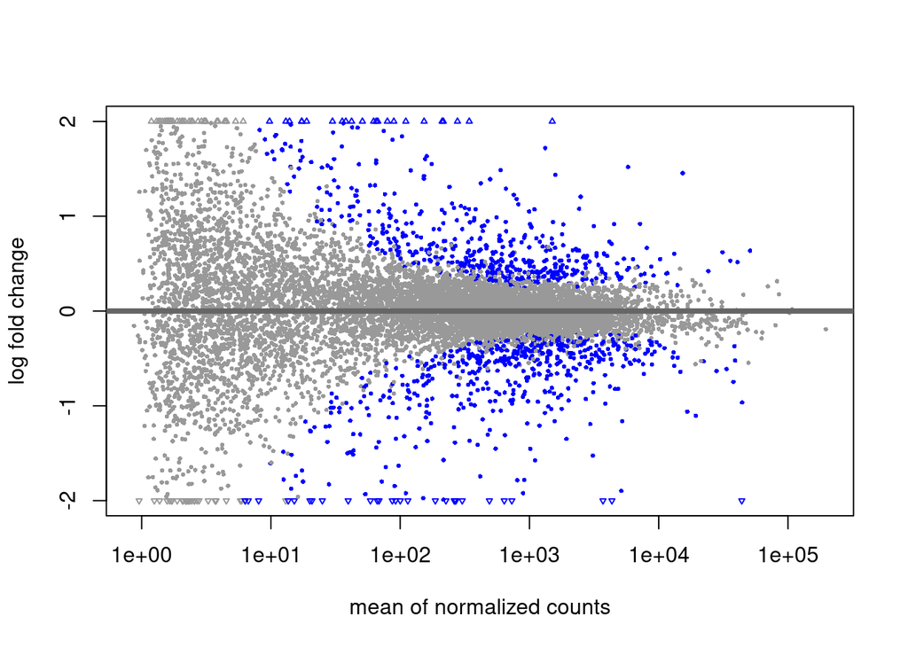

```r
plotMA(res, ylim=c(-2,2))
```

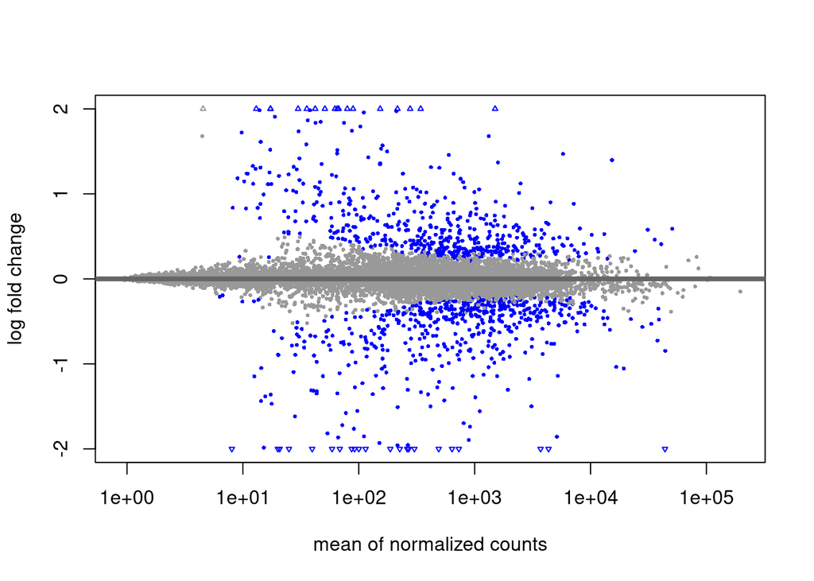

```r
plotMA(resLFC, ylim=c(-2,2))
```

```r
# Intenta esto si quieres marcar algunos puntos manualmente
# No te olvides de correr esto en la terminal y no en el Rmarkdown!

#plotMA(resLFC, ylim=c(-2,2))
#idx <- identify(res$baseMean, res$log2FoldChange)
#rownames(res)[idx]
```

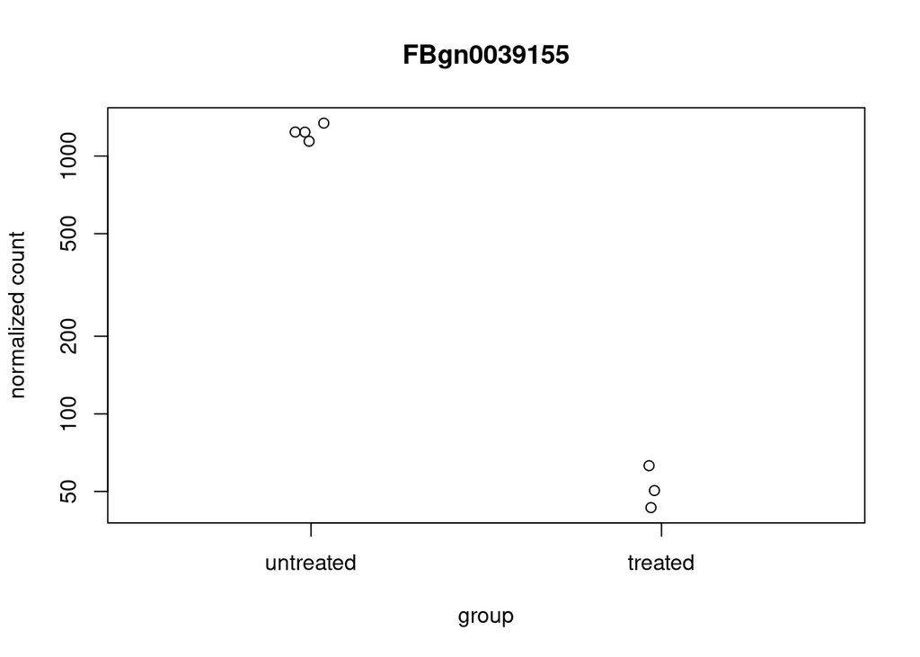

```r
plotCounts(dds, gene=which.min(res$padj), intgroup="condition")
```

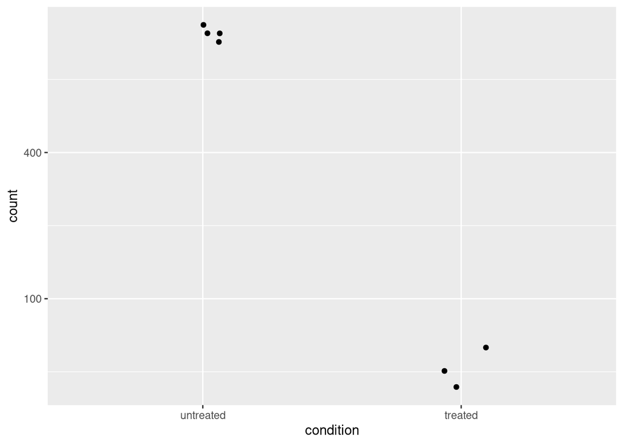

```r
d <- plotCounts(dds, gene=which.min(res$padj), intgroup="condition",
                returnData=TRUE)
library("ggplot2")
ggplot(d, aes(x=condition, y=count)) +
  geom_point(position=position_jitter(w=0.1,h=0)) +
  scale_y_log10(breaks=c(25,100,400))
```

```r
resSig <- subset(resOrdered, padj < 0.1)
resSig
```

```
## log2 fold change (MLE): condition treated vs untreated
## Wald test p-value: condition treated vs untreated
## DataFrame with 1054 rows and 6 columns
##              baseMean log2FoldChange     lfcSE      stat       pvalue
##             <numeric>      <numeric> <numeric> <numeric>    <numeric>
## FBgn0039155   730.568       -4.61874 0.1691240  -27.3098 3.24447e-164
## FBgn0025111  1501.448        2.89995 0.1273576   22.7701 9.07165e-115
## FBgn0029167  3706.024       -2.19691 0.0979154  -22.4368 1.72030e-111
## FBgn0003360  4342.832       -3.17954 0.1435677  -22.1466 1.12417e-108
## FBgn0035085   638.219       -2.56024 0.1378126  -18.5777  4.86845e-77
## ...               ...            ...       ...       ...          ...
## FBgn0037073  973.1016      -0.252146 0.1009872  -2.49681    0.0125316
## FBgn0029976 2312.5885      -0.221127 0.0885764  -2.49645    0.0125443
## FBgn0030938   24.8064       0.957645 0.3836454   2.49617    0.0125542
## FBgn0039260 1088.2766      -0.259253 0.1038739  -2.49585    0.0125656
## FBgn0034753 7775.2711       0.393515 0.1576749   2.49574    0.0125696
##                     padj
##                <numeric>
## FBgn0039155 2.71919e-160
## FBgn0025111 3.80147e-111
## FBgn0029167 4.80595e-108
## FBgn0003360 2.35542e-105
## FBgn0035085  8.16049e-74
## ...                  ...
## FBgn0037073    0.0999489
## FBgn0029976    0.0999489
## FBgn0030938    0.0999489
## FBgn0039260    0.0999489
## FBgn0034753    0.0999489
```

```r
write.csv(as.data.frame(resOrdered),
          file="condition_treated_results.csv")

write.csv(as.data.frame(resSig),
          file="condition_treated_results_padj_0.01.csv")
```

```r
# Break para aprender biomaRt

library(biomaRt)
listEnsembl()
```

```
##         biomart                version
## 1         genes      Ensembl Genes 104
## 2 mouse_strains      Mouse strains 104
## 3          snps  Ensembl Variation 104
## 4    regulation Ensembl Regulation 104
```

```r
ensembl <- useEnsembl(biomart = "genes")
datasets <- listDatasets(ensembl)
ensembl <- useDataset(dataset = "dmelanogaster_gene_ensembl", mart = ensembl)
filters <- listFilters(ensembl)
attributes <- listAttributes(ensembl)

ensembl_drosophila <- getBM(attributes = c("ensembl_gene_id","external_gene_name"),
      filters =  "ensembl_gene_id",
      values = list(rownames(resSig)),
      mart = ensembl)

resSig2 <- data.frame(ensembl_gene_id = rownames(resSig), resSig)
resSig3 <- merge(ensembl_drosophila, resSig2, by="ensembl_gene_id")

write.csv(as.data.frame(resSig3),
          file="condition_treated_results_padj_0.01.csv")
```

## Extrayendo los valores transformados

```r
vsd <- vst(dds, blind=FALSE)
head(assay(vsd),3)
```

```
##              treated1  treated2  treated3 untreated1 untreated2 untreated3
## FBgn0000008  7.607917  7.834912  7.595052   7.567298   7.642174   7.844603
## FBgn0000014  6.318818  6.041221  6.041221   6.412782   6.173921   6.041221
## FBgn0000017 11.938311 12.024557 12.013565  12.045721  12.284647  12.455939
##             untreated4
## FBgn0000008   7.669147
## FBgn0000014   6.041221
## FBgn0000017  12.077404
```

# Heatmap

```r
library(pheatmap)
select <- order(rowMeans(counts(dds,normalized=TRUE)),
                decreasing=TRUE)[1:20]
select
```

```
##  [1]  152  154 9085  538  244  325    8 7623 2227  476 2045  286   86 1833  776
## [16] 1104  635  253  928  349
```

```r
df <- as.data.frame(colData(dds)[,c("condition","type")])
df
```

```
##            condition        type
## treated1     treated single-read
## treated2     treated  paired-end
## treated3     treated  paired-end
## untreated1 untreated single-read
## untreated2 untreated single-read
## untreated3 untreated  paired-end
## untreated4 untreated  paired-end
```

## Heatmap

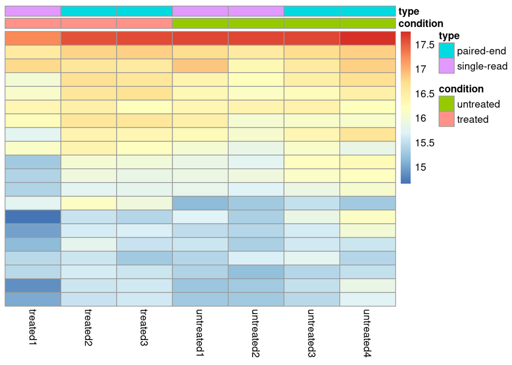

```r
pheatmap(assay(vsd)[select,], cluster_rows=FALSE, show_rownames=FALSE,
         cluster_cols=FALSE, annotation_col=df)
```

## Gráfico de componentes principales

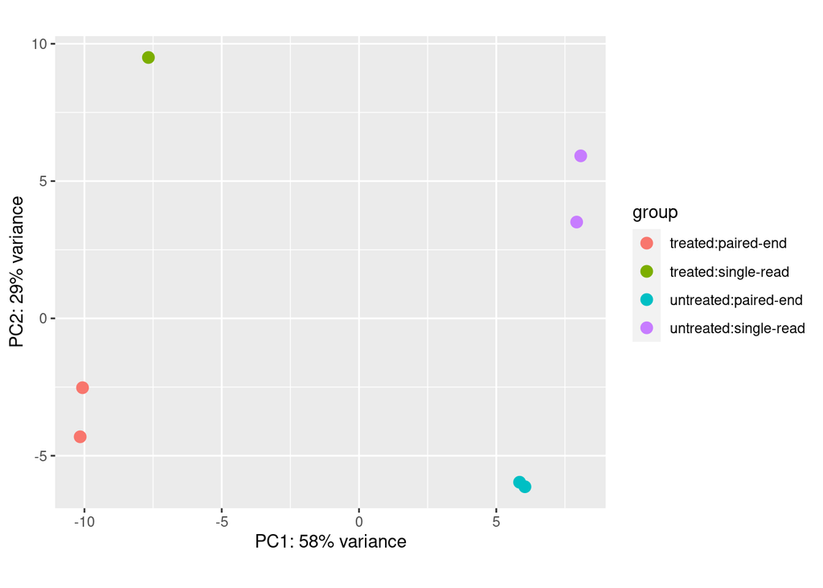

```r
plotPCA(vsd, intgroup=c("condition", "type"))
```

```r
pcaData <- plotPCA(vsd, intgroup=c("condition", "type"), returnData=TRUE)
pcaData
```

```
##                   PC1       PC2                 group condition        type
## treated1    -7.669697  9.500618   treated:single-read   treated single-read
## treated2   -10.069653 -2.523187    treated:paired-end   treated  paired-end
## treated3   -10.155468 -4.310416    treated:paired-end   treated  paired-end
## untreated1   8.075664  5.919303 untreated:single-read untreated single-read
## untreated2   7.927423  3.508276 untreated:single-read untreated single-read
## untreated3   6.043480 -6.129764  untreated:paired-end untreated  paired-end
## untreated4   5.848252 -5.964831  untreated:paired-end untreated  paired-end
##                  name
## treated1     treated1
## treated2     treated2
## treated3     treated3
## untreated1 untreated1
## untreated2 untreated2
## untreated3 untreated3
## untreated4 untreated4
```

```r
percentVar <- round(100 * attr(pcaData, "percentVar"))
percentVar
```

```
## [1] 58 29
```

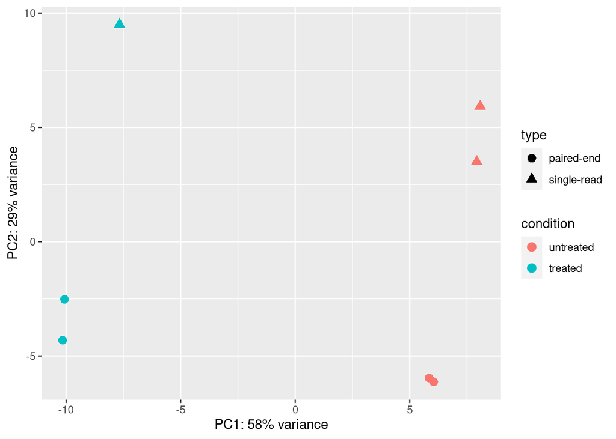

```r
ggplot(pcaData, aes(PC1, PC2, color=condition, shape=type)) +
  geom_point(size=3) +
  xlab(paste0("PC1: ",percentVar[1],"% variance")) +
  ylab(paste0("PC2: ",percentVar[2],"% variance")) +
  coord_fixed()
```